# Access static files from the web using R

## Access static files from the web using R

### STEP 0 - Load the libraries and request parameters

```r
library(sf) # -> for spatial data handling
library(rnaturalearth) # -> for spatial data
library(ggplot2) # -> for plotting
```

### STEP 1 - Import the data

```r
# STEP 1 - Download and read the shapefile
# Download and unzip the file
shp_url <- "https://www.donneesquebec.ca/recherche/dataset/f0250998-eac1-46a8-8e0c-d7278ae85506/resource/7d1ba01c-d251-460e-972b-7dcde6cf2fe0/download/registre_aires_prot.zip"

download.file(shp_url, "registre_aires_prot.zip")
unzip("registre_aires_prot.zip", exdir = ".")
```

### STEP 2 - Data manipulation and cleaning

Since the shapefile is in the ESRI Shapefile format, we can use the `sf` package to read the data into R. The `st_read()` function reads the shapefile and returns an `sf` object.

The `sf` object is a data frame with a special attribute called `geometry`. The `geometry` attribute contains the spatial information of the data, such as points, lines, or polygons. The `sf` package provides functions to manipulate and visualize spatial data in vector format.

```r
# Read the shapefile
shp <- sf::st_read("registre_aires_prot/AP_REG_S.shp")
# Data summary
print(shp)
```

```
#> Simple feature collection with 5137 features and 20 fields
#> Geometry type: MULTIPOLYGON
#> Dimension:     XY
#> Bounding box:  xmin: -826213.6 ymin: 119629.8 xmax: 783723 ymax: 2087104
#> Projected CRS: NAD83 / Quebec Lambert
#> First 10 features:
#>    MACODE                                                                             TOPONYME                      NOM ARTICLE DESIG_NO
#> 1   12278                                                          Refuge biologique 07152R017                07152R017    <NA>       39
#> 2   12348                                                          Refuge biologique 07351R034                07351R034    <NA>       39
#> 3    7599                                                          Refuge biologique 08764R028                08764R028    <NA>       39
#> 4    7199                                                          Refuge biologique 08551R036                08551R036    <NA>       39
#> 5    6750    Habitat d'une espèce floristique menacée ou vulnérable du Marais-de-l'Anse-du-Cap  Marais-de-l'Anse-du-Cap      du        8
#> 6     135                                                                  Parc national d'Oka                      Oka      d'        9
#> 7    6734 Habitat d'une espèce floristique menacée ou vulnérable de l'Alvar-de-l'Île-de-Pierre Alvar-de-l'Île-de-Pierre   de l'        8
#> 8    6748     Habitat d'une espèce floristique menacée ou vulnérable du Marais-de-l'Anse-Verte   Marais-de-l'Anse-Verte      du        8
```

[output cut: 57 more lines]

The coordinates geometry of the data is projected in the Quebec Lambert Conformal Conic projection (EPSG: 32198), meaning that the coordinates are in meters in a cartesian system.

Projected coordinates are better suited for spatial analysis and visualization because they preserve the shape of the features. Projecting the data to a specific coordinate reference system (CRS) is essential for spatial analysis and visualization.

### STEP 3 - Visualize the data

The `ggplot2` package is a powerful tool for creating visualizations in R. The `geom_sf()` function from the `ggplot2` package can be used to plot spatial data stored in an `sf` object.

`rnaturalearth` package provides easy access to geometry for cultural and physical features of the world. We can use the `ne_states()` function to get the geometry of the provinces of Canada and plot the protected areas over the province of Quebec.

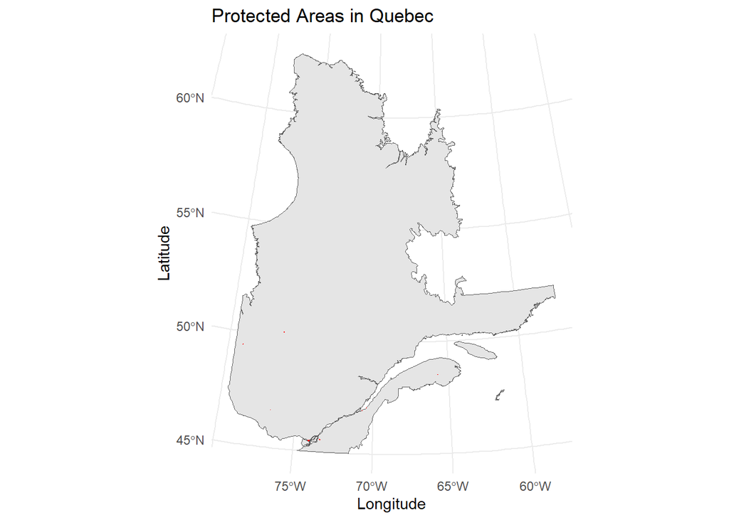

```r
# Plot the first 10 polygons over the province of Quebec
# Get the province of Quebec and project the data to the same CRS
quebec <- ne_states(country = "canada", returnclass = "sf") |>
  dplyr::filter(name_en == "Quebec") |>
  st_transform(st_crs(shp))

# Plot the data
ggplot() +
  geom_sf(data = quebec) +
  geom_sf(data = shp[1:10, ], color = "red", fill = NA, size = 2) +
  theme_minimal() +
  labs(title = "Protected Areas in Quebec",
       x = "Longitude", y = "Latitude")
```